# Module 5: Peer Reviewed Assignment

#### 3. (a) Initial Inspection

Load in the data from local directory and create a linear model with `Gross` as the response and `Budget` as the feature. The data is stored in the same local directory and is called `bollywood_boxoffice.csv`. Thank the University of Florida for this specific dataset.

Specify whether each of the four regression model assumptions are being violated.

Data Source: http://www.bollymoviereviewz.com

```
                  Movie         Gross            Budget
 1920London          :  1   Min.   :  0.63   Min.   :  4.00
 2 States\xa0        :  1   1st Qu.:  9.25   1st Qu.: 19.00
 24(Tamil,Telugu)    :  1   Median : 29.38   Median : 34.50
 Aashiqui 2          :  1   Mean   : 53.39   Mean   : 45.25
 AeDilHainMushkil\xa0:  1   3rd Qu.: 70.42   3rd Qu.: 70.00
 AGentleman          :  1   Max.   :500.75   Max.   :150.00
 (Other)             :184
```

```
Call:
lm(formula = Gross ~ Budget, data = bollywood)

Residuals:
    Min      1Q  Median      3Q     Max
-140.48  -21.39   -6.06    7.27  399.36

Coefficients:
            Estimate Std. Error t value Pr(>|t|)
(Intercept)   -9.120      6.112  -1.492    0.137
Budget         1.381      0.108  12.792   <2e-16 ***
---
Signif. codes:  0 ‘***’ 0.001 ‘**’ 0.01 ‘*’ 0.05 ‘.’ 0.1 ‘ ’ 1

Residual standard error: 50.6 on 188 degrees of freedom
Multiple R-squared:  0.4653,	Adjusted R-squared:  0.4625
F-statistic: 163.6 on 1 and 188 DF,  p-value: < 2.2e-16
```

```
 Named num [1:190] 55.03 -41.6 -5.19 -1.82 1.19 ...
 - attr(*, "names")= chr [1:190] "1" "2" "3" "4" ...
```

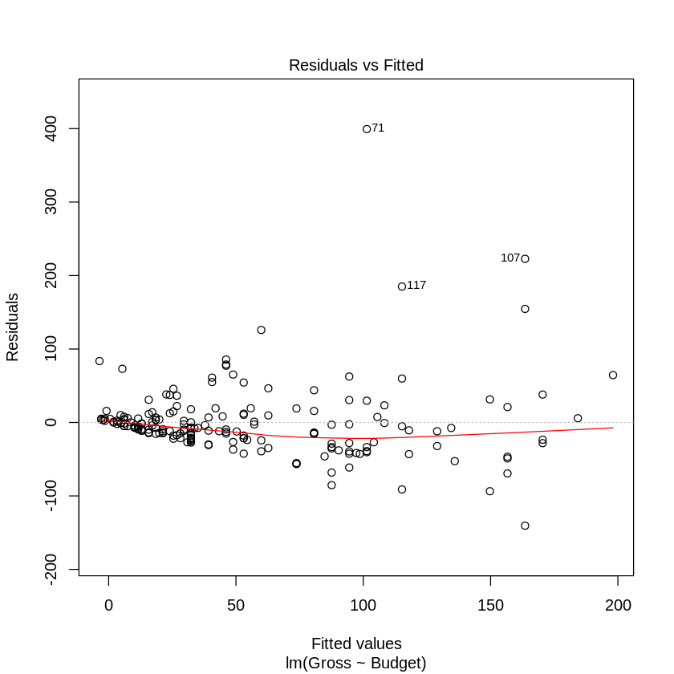

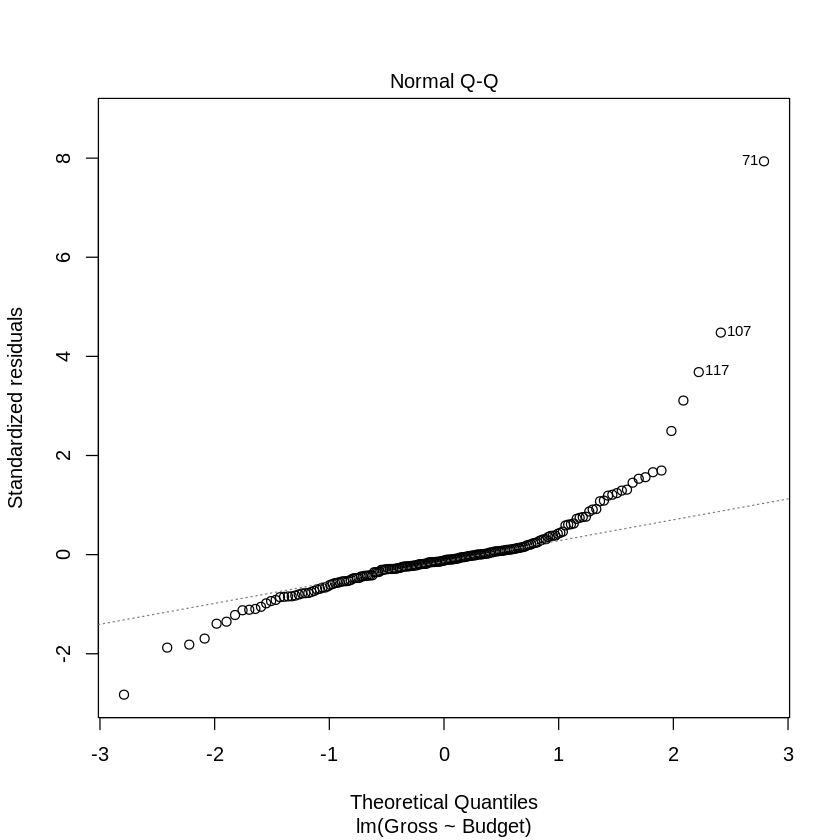

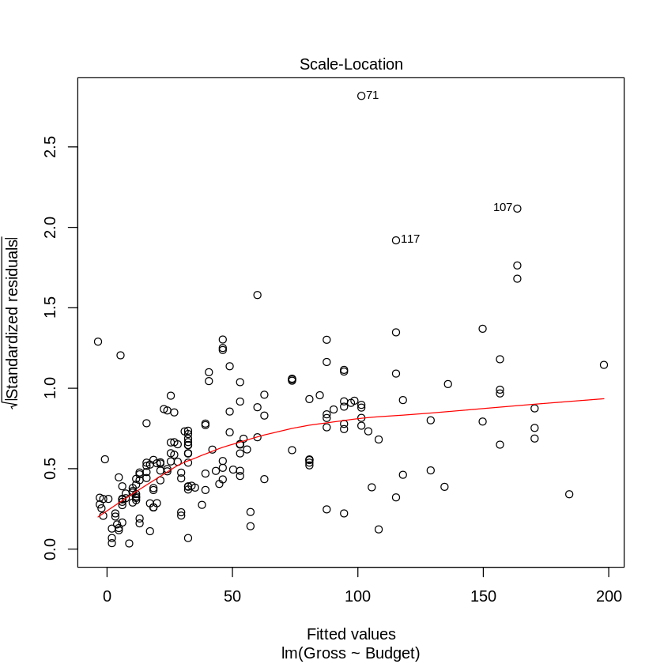

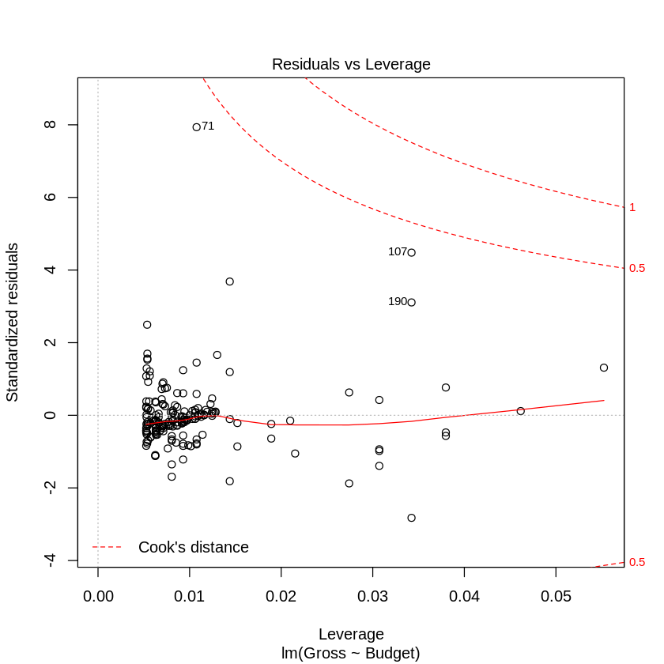

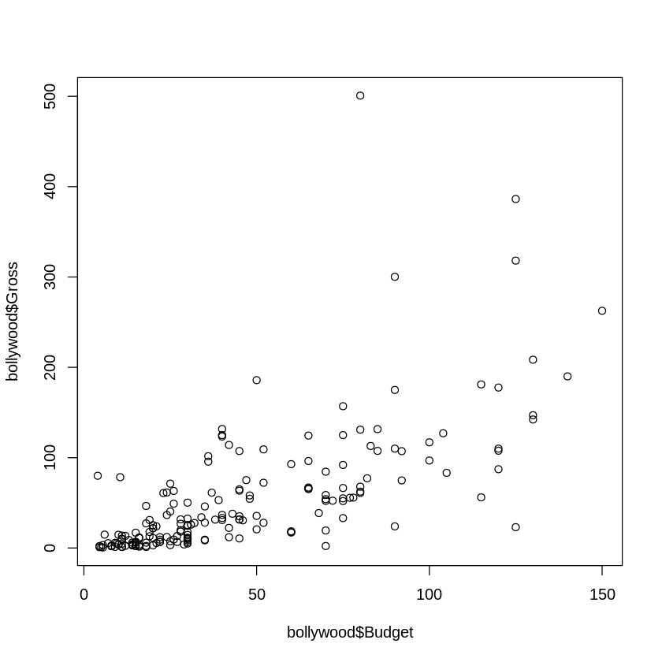

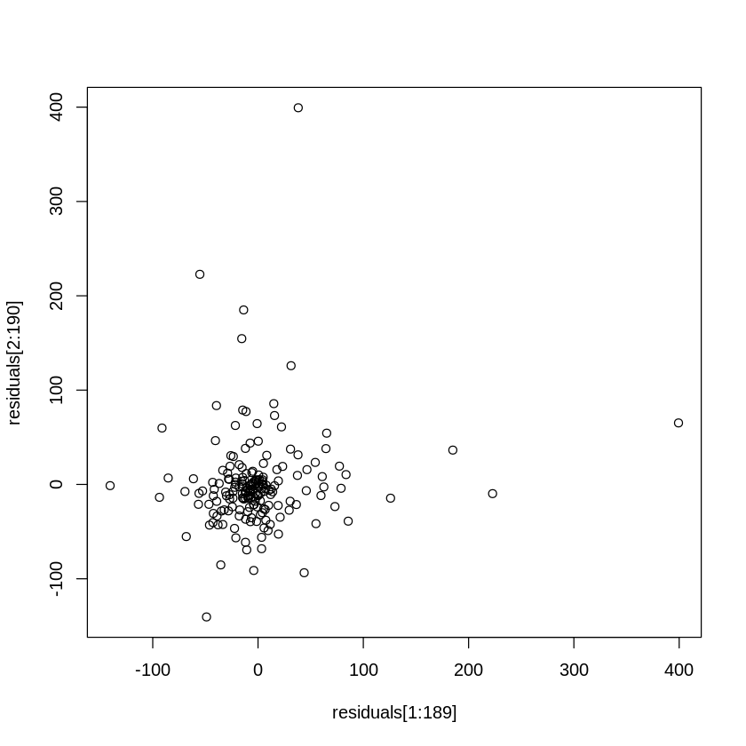

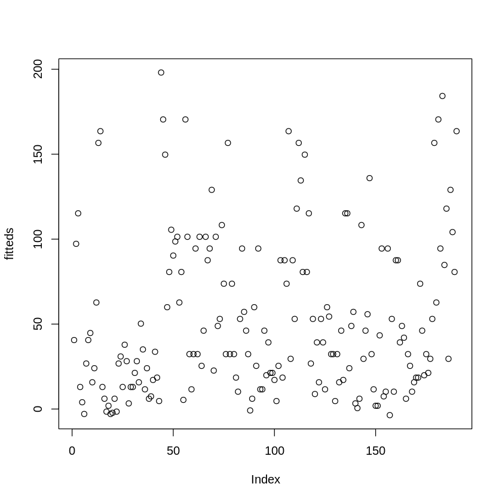

```r
# Load the data
bollywood = read.csv("bollywood_boxoffice.csv")
summary(bollywood)

# Your Code Here
bol_lm <- lm(Gross ~ Budget, data = bollywood)
summary(bol_lm)

fitteds <- fitted(bol_lm)
residuals <- resid(bol_lm)
str(residuals)

plot(bol_lm)
plot(bollywood$Budget, bollywood$Gross)
plot(residuals[1:189], residuals[2:190])
plot(fitteds)
```

#### 3. (b) Transformations

Notice that the Residuals vs. Fitted Values plot has a 'trumpet" shape to it, the points have a greater spread as the Fitted value increases. This means that there is not a constant variance, which violates the homoskedasticity assumption.

So how do we address this? Sometimes transforming the predictors or response can help stabilize the variance. Experiment with transfomrations on `Budget` and/or `Gross` so that, in the transformed scale, the relationship is approximately linear with a constant variance. Limit your transformations to square root, logarithms and exponentiation.

Note: There may be multiple transformations that fix this violation and give similar results. For the purposes of this problem, the transformed model doesn't have the be the "best" model, so long as it maintains both the linearity and homoskedasticity assumptions.

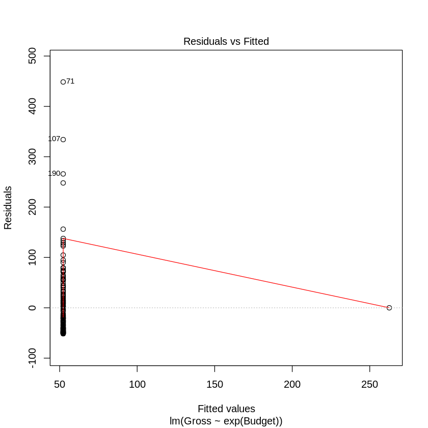

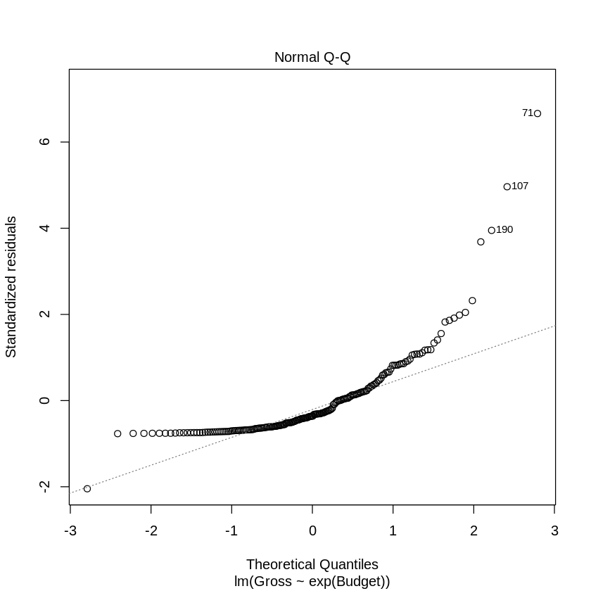

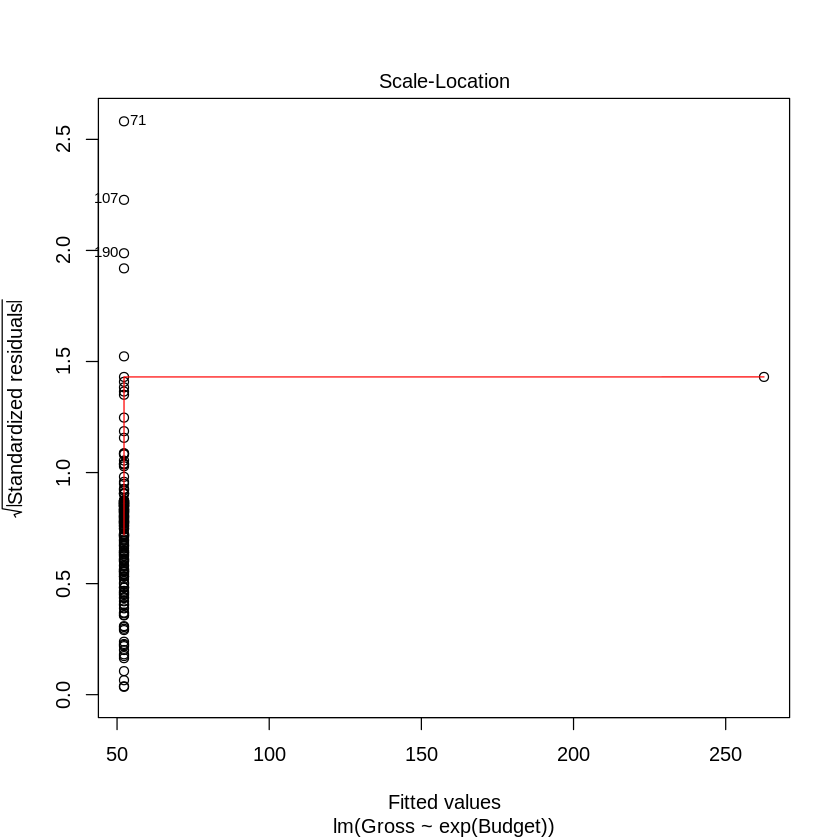

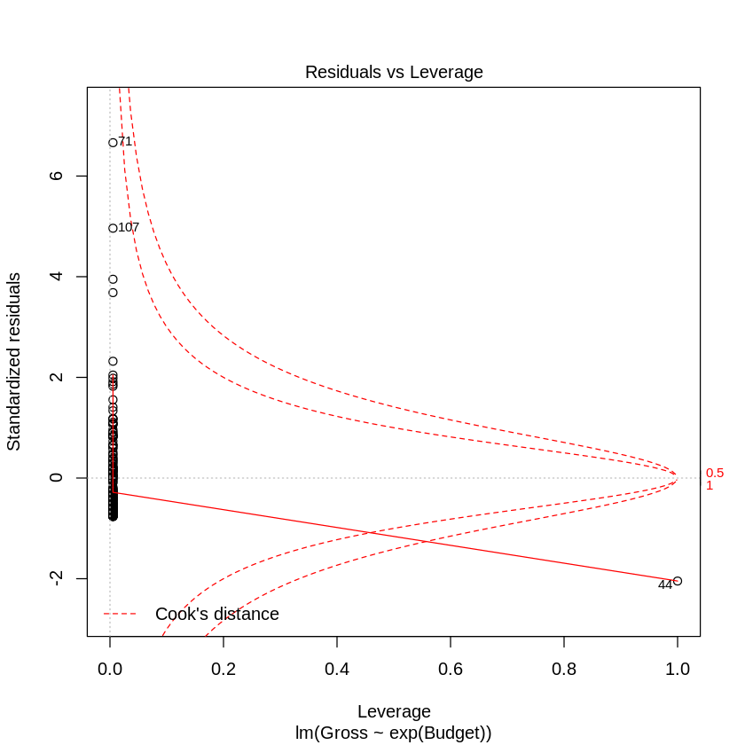

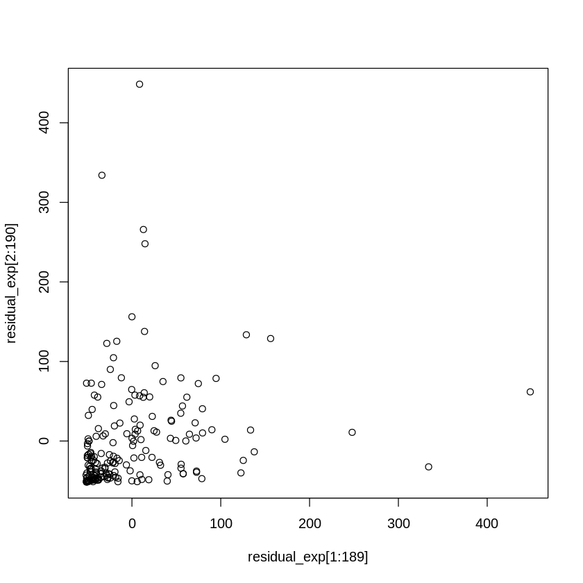

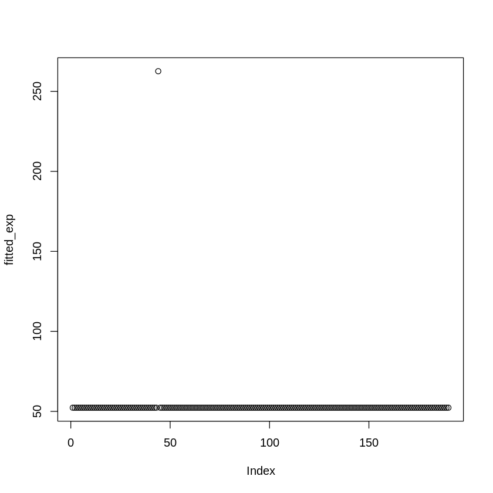

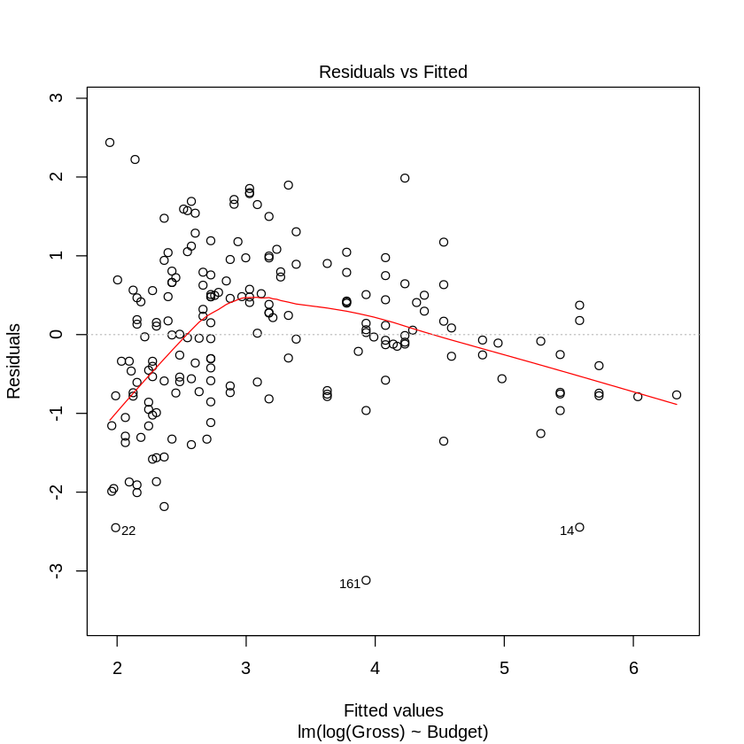

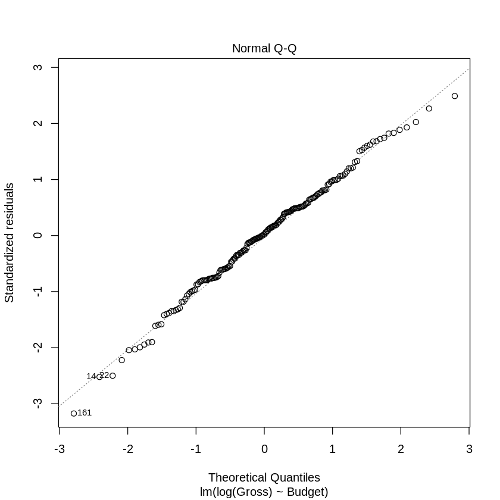

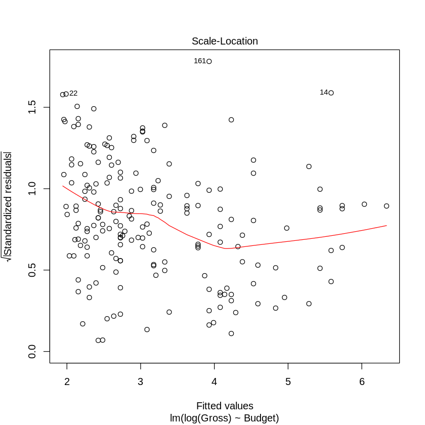

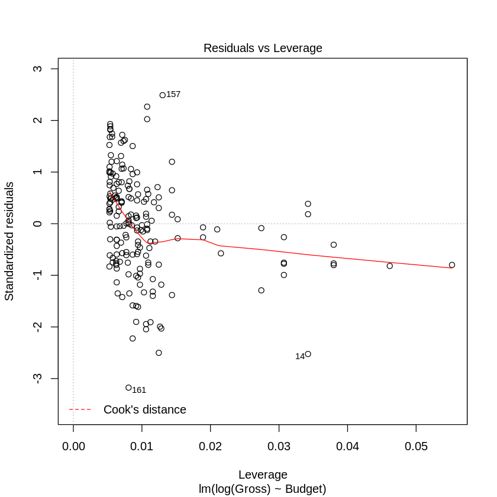

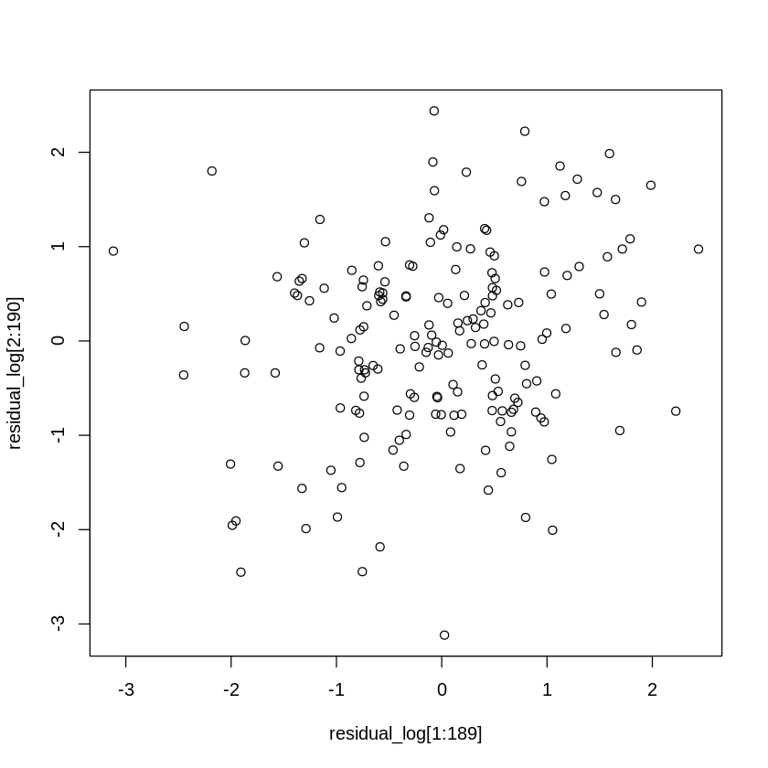

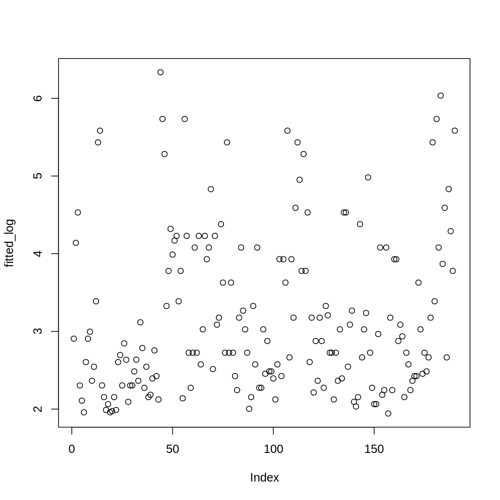

[6 more figures not shown]

```r
# Your Code Here
exp_mod <- lm(Gross ~ exp(Budget), data = bollywood)
#exp_mod <- lm(exp(Gross) ~ Budget, data = bollywood)
plot(exp_mod)

fitted_exp <- fitted(exp_mod)
residual_exp <- resid(exp_mod)

plot(residual_exp[1:189], residual_exp[2:190])
plot(fitted_exp)

log_mod <- lm(log(Gross) ~ Budget, data = bollywood)
plot(log_mod)

fitted_log <- fitted(log_mod)
residual_log <- resid(log_mod)

plot(residual_log[1:189], residual_log[2:190])
plot(fitted_log)

#Best model
sqrt_mod <- lm(sqrt(Gross) ~ Budget, data = bollywood)
plot(sqrt_mod)

fitted_sqrt <- fitted(sqrt_mod)
residual_sqrt <- resid(sqrt_mod)

plot(residual_sqrt[1:189], residual_sqrt[2:190])
plot(fitted_sqrt)

sqrt_mod$coefficients
```

[output not shown]

#### 3. (c) Interpreting Your Transformation

You've fixed the nonconstant variance problem! Hurray! But now we have a transformed model, and it will have a different interpretation than a normal linear regression model. Write out the equation for your transformed model. Does this model have an interpretation similar to a standard linear model?

Model equation: $$ \sqrt{Gross} = 2.1657 + 0.0881 * Budget $$